# Chu_Yiwei_yc878_finalproject

Yiwei Chu

12/2/2019

# Problem statement and background

- Problem Statement: In this project, I hope to research percentage of alcohol use disorder population, because it has been a serious social issue and many friends of mine are suffering from the disorder. I collected data from worldbank and our world in data, where each row is a country’s name data for each year from 2008 to 2017. After cleaning it, it has 1067 rows of observations and 15 columns, and I choose Drug use disorder, Age Dependency Ratio, GDP, GNI, Labor Force, Primary School Enrollment, Refugee Population, Unemployment, Population and sex ratio as predicators. I hope to calculate correlation to study the relationship between attributes, the importance of predictors, and create different models(Linear Regression Model, K-Nearest Neighbors Model, Random Forest Model) to predict the percentage of alcohol use disorder population.
- Data Background
- Data sources: World Bank, Our World in Data
- Data variables: AUD, DUD, Age Dependency Ratio, GDP, GNI, Labor Force, Primary School Enrollment, Refugee Population, Unemployment, Population, Male Population, Female Population.
- Data distribution: Most of the data are right-skewed, only the distribution of primary school enrollment data is close to normal distribution.

# Methods/Tools I use and the rational for that use

- Methods -Data wrangling: I mainly use “select”, “mutate”, “gather” and “filter” to clean the data and use “merge” to combine all the data frames into one data frame.
- Use 75% data as train data and 25% data as test data
- Supervised Learning(Regression) Since the outcome is numeric, I use Regression instead of classification. I basiclly use three models. -Linear Regression -K-Nearest Neighbors -Random Forest After running these models, I examine which model fits best through calculating RMESE and Rsquared, then I calculate the MSE of the best fit model.
- Data visualization I mainly visualize the distribution of predicators, K-Nearest neighbors model, Random forest model, the relationship between variables and the variable importance. The reason why I want to visualize these is because that is the most intuitive way, and we can see a lot from the pictures.
- Examine Variable Importance I use importance function to examine the variable importance to be clear which variable is the most importance when predicating the outcome.
- Tools (readr), (tidyverse), (reshape), (caret), (recipes), (pdp), (vip), (ggplot2)

# Visualize the correlation

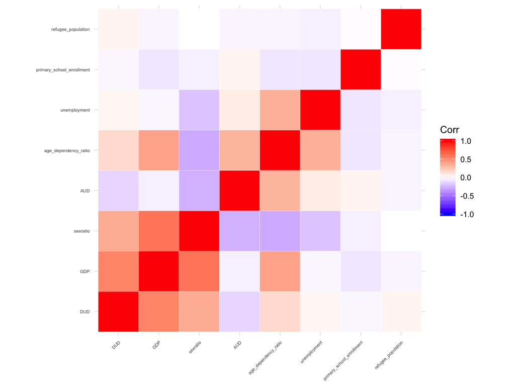

# Plot for mod_knn

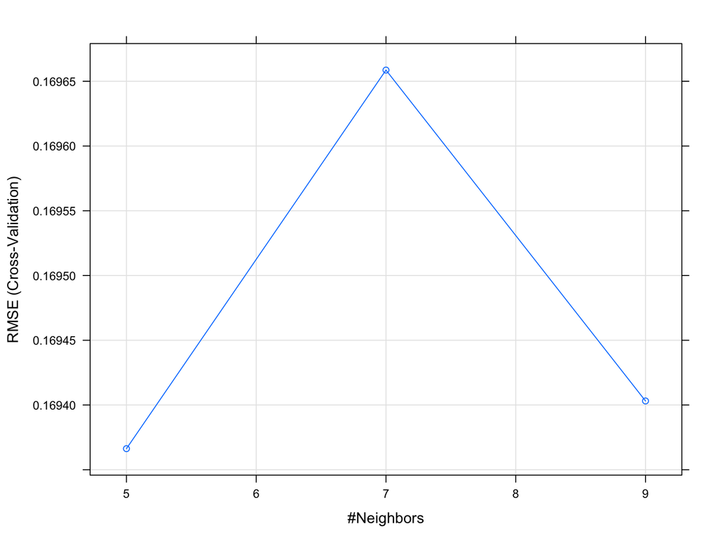

# Plot for mod_rf

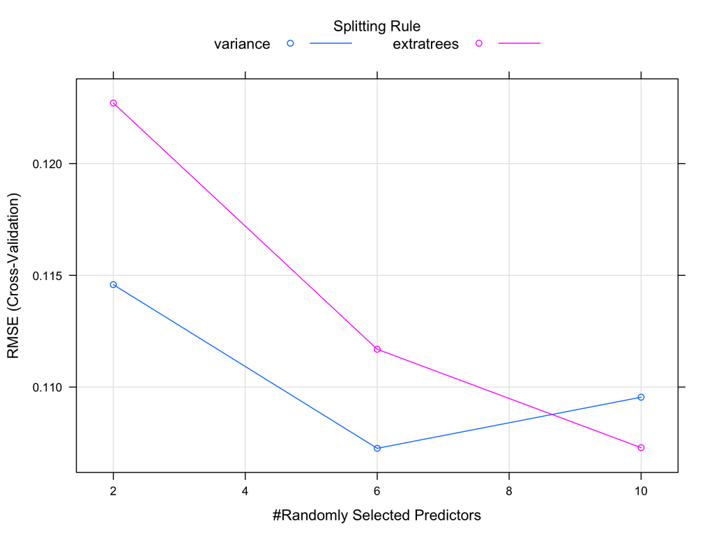

```r
plot(mod_rf)
```

# Examine the error across each of the models.

-Linear Regression has the biggest error, while random forest model has the smallest error.

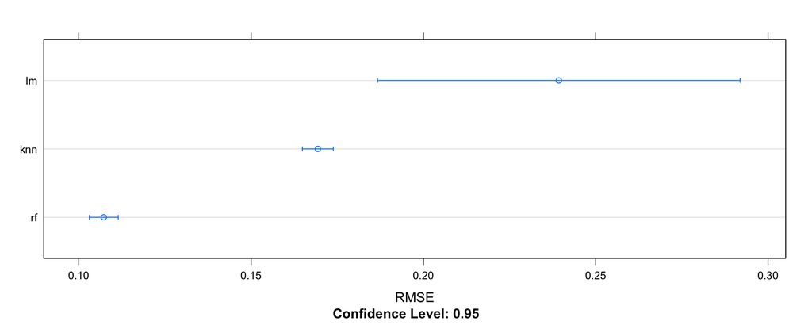

# Examine the fit across each of the models.

-Random forest model has the biggest Rsquare, meaning that it performs the best. Therefore, we will choose Random forest model.

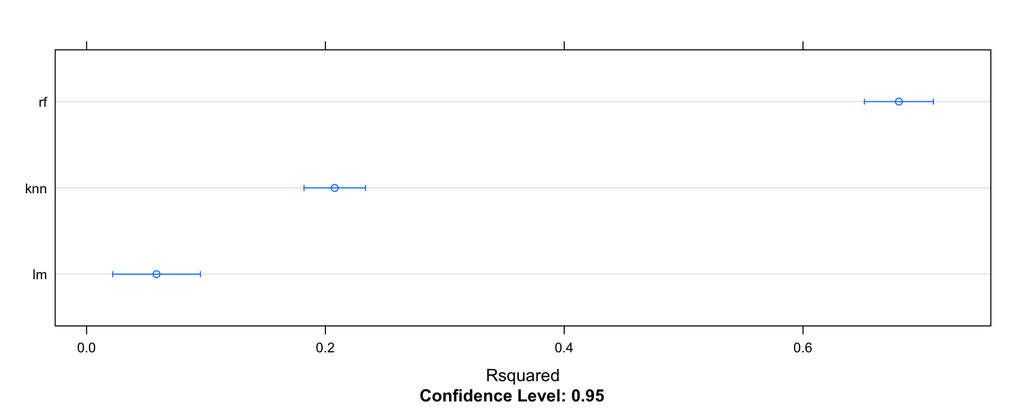

- Test the Predictive Accuracy of the Best Model

```r
pred <- predict(mod_rf,newdata = test_data2)
mse = sum(test_data2$AUD-pred^2)/nrow(test_data2)
mse
```

```
## [1] 0.1469433
```

# Examine the variable importance

-Sex ratio is the most important variable, and Drug use disorder is the second important variable, then age dependency ratio is the third important variable.

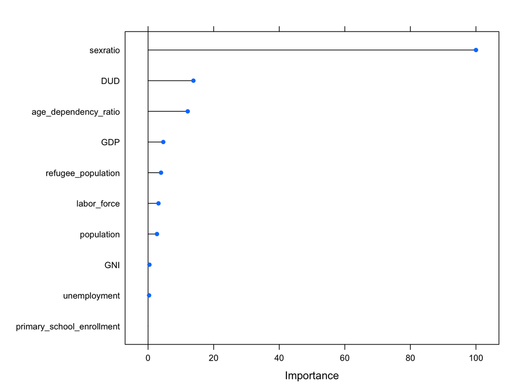

```r
plot(varImp(mod_rf,scale=T),top = 10)
```

# Lessons learned and Plans

- Choosing predicators The predicators should be less corrlated with each other（Population, Population_male, Population_female）
- Dropping NA or Imputing NA? We usually don’t drop all the NA easily since NA mean a lot of things. When the data is skewed, we usually use median to fill the NA, and when the data is not skewed, we use mean to fill the numeric NA and mode to fill the NA. Therefore, my biggest challenge is about the NA. My next step will be analyzing the NA to see the reason behind it and making decisions of dropping it or imputing it.